# Lecture

## Change point

A **change point** is the change of the statistical properties of the series. The change point detection problem is to identify the change moment.

## Example applications

Detection of:

- malicious traffic in networks
- anomalies in video surveillance
- failures in vehicles
- changes in material during drilling
- economic events (recession)
- stock price changes
- arrhythmias
- ...

## Definitions

- Consider a random process $\xi_1, \xi_2, \ldots, \xi_{\theta-1}, \xi_\theta, \xi_{\theta+1}, \ldots$ with realization $X_1, X_2, \ldots, X_{\theta-1}, X_\theta, X_{\theta+1}, \ldots$
- $\theta$ is the change point that we want to estimate
- Introduce $P_{\infty}$ - the distribution of $\xi$ if $\theta = \infty$ (no changepoint, always normal regime), and corresponding density $f_{\infty}$
- Introduce $P_0$ - the distribution of $\xi$ if $\theta = 0$ (changepoint at the beginning, always abnormal regime), and corresponding density $f_0$
- Introduce $P_{\theta}$ - the distribution of $\xi$ if $0 < \theta < \infty$, and corresponding density $f_{\theta}(X) = f_{\infty}(X_1, \ldots, X_{\theta-1}) f_0(X_\theta, \ldots, X_n)$

[figure not shown]

## Definitions

- **Stopping time** $\tau$ is when to give an alarm that a change happened. Stopping time is the statistic of observations $\tau = \tau(X)$.
- False Detection Delay $\operatorname{FDD}(\tau) = \mathbb{E}_\infty[\tau] \to \infty$
- Probability of False Alarm $\operatorname{PFA}(\tau) = \mathbb{P}_\theta(\tau < \theta) \to 0$
- Average Detection Delay $\operatorname{ADD}(\tau) = \mathbb{E}_0[\tau] = \mathbb{E}_\theta[\tau - \theta | \tau > \theta] \to 0$

[figure not shown]

## Methods

Methods for change point detection fall under two categories:

- Offline: when all data is available at once, including data after changepoint
- Online: when only observed data is available

Typically, such a method consists of:

- A cost function or a statistic that is higher in the presence of a changepoint and lower without
- A method to search for changepoints
- A constraint on the number of changepoints (for offline methods)

## Simple methods: Exponential Weighted Moving Average

- Estimate the moving average $$ m_k = (1 - \lambda) m_{k-1} + \lambda X_k $$
- If the moving average exceeds a certain value, report an alarm $$ \tau = \min\{k: m_k > h\} $$
- Alternatively, estimate the moving average of log-likelihood

## Optimality conditions

- We fix one measure (ADD or FDD) and optimize with respect to the other
- Criterion A: fix $\operatorname{PFA}(\tau) < c$ and search for $A(c) = \min_\tau \operatorname{ADD(\tau)}$
- Criterion C: fix $\operatorname{FDD}(\tau) \geqslant T$ and search for $C(T) = \min_\tau \max_\theta \operatorname{ADD(\tau)}$
- Criterion D: same as C, but probabilistic

## Optimal methods: CUSUM

- CUSUM statistic: $$ T_n = \max (0, T_{n-1} + \zeta_n) $$ where $\zeta_n$ is typically log-likelihood.
- Stopping time: $$ \tau_{CUSUM} = \inf \{ n \geqslant 0: T_n \geqslant h \} $$
- CUSUM is optimal w.r.t. criterion D

## Optimal methods: Shiryaev-Roberts statistic

- Shiryaev-Roberts statistic: $$ R_t = (1 + R_{t-1}) l_t $$ where $l_t$ is the likelihood ratio for two hypotheses
- Stopping time: $$ \tau_{SR} = \inf \{ n \geqslant 0: R_n \geqslant h \} $$
- Shiryaev-Roberts statistic is optimal w.r.t. criterion C

## Optimal methods: Posterior probability statistic

- Posterior probability statistic: $$ \pi_n = \mathbb{P}(\theta \leqslant n | X_1, \ldots, X_n) $$
- Stopping time: $$ \tau_\pi = \inf \{ n \geqslant 0: \pi_n \geqslant h \} $$
- Posterior probability statistic is optimal w.r.t. criterion A

## Multivariate CPD: Maximum Mean Discrepancy

$$ \operatorname{MMD}(X, Y) = \frac{1}{C_m^2} \sum_{i\neq j} k(x_i, x_j) + \frac{1}{C_m^2} \sum_{i\neq j} k(y_i, y_j) - \frac{2}{m^2} \sum_{i, j} k(x_i, y_j) $$

# Webinar

```python
!pip install ruptures
```

## Synthetic data

```
[87, 173, 259, 340, 420, 500]
```

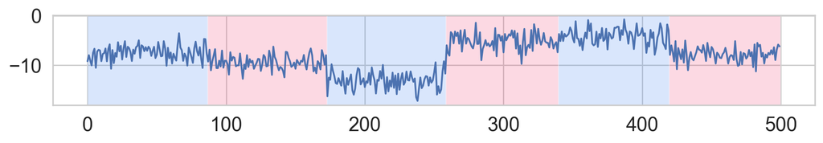

```python
n_samples, n_dims, sigma = 500, 1, 1.5
n_cps = 5
signal, cps = rpt.pw_constant(n_samples, n_dims, n_cps, noise_std=sigma, seed=27)
print(cps)
rpt.display(signal, cps);
```

## Models

Considered models are detecting changes in mean of the underlying process:

- Binseg: splits initial task into a sequence of CPD tasks with AMOC (at most one changepoint) assumption
- Dynp: same but uses dynamic programming
- PELT: uses cost function with penalty
- KernelCPD: maps signal into RKHS and performs CPD there

Each of these methods can have different cost functions.

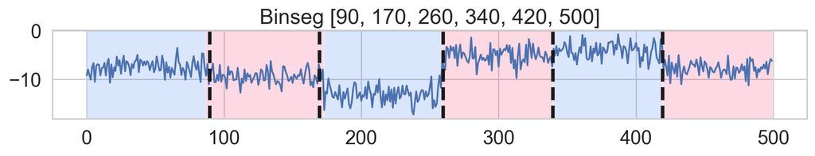

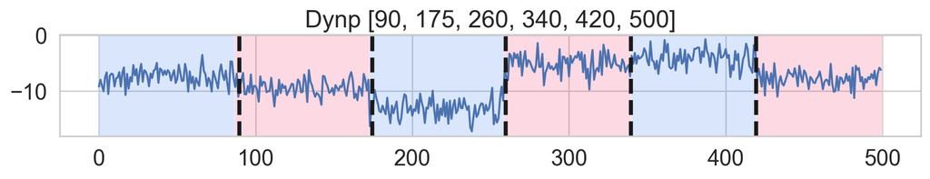

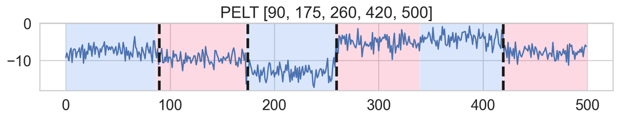

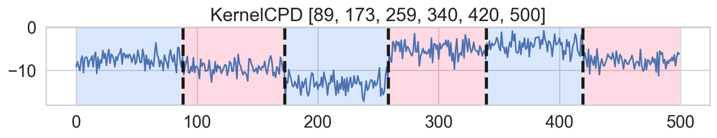

```python
results_dict = dict()

algo = rpt.Binseg(model="l2").fit(signal)
result_binseg = algo.predict(n_bkps=n_cps)
results_dict["binseg"] = result_binseg

fig, ax = rpt.display(signal, cps, result_binseg)
ax[0].set_title(f"Binseg {result_binseg}")

algo = rpt.Dynp(model="l2").fit(signal)
result_dynp = algo.predict(n_bkps=n_cps)
results_dict["dynp"] = result_dynp

fig, ax = rpt.display(signal, cps, result_dynp)
ax[0].set_title(f"Dynp {result_dynp}")

algo = rpt.Pelt(model="l2").fit(signal)
result_pelt = algo.predict(pen=50)
results_dict["pelt"] = result_pelt

fig, ax = rpt.display(signal, cps, result_pelt)
ax[0].set_title(f"PELT {result_pelt}")

algo = rpt.KernelCPD(kernel="rbf").fit(signal)
result_kernel = algo.predict(n_bkps=n_cps)
results_dict["kernel"] = result_kernel

fig, ax = rpt.display(signal, cps, result_kernel)
ax[0].set_title(f"KernelCPD {result_kernel}");
```

## Evaluation

1. **Classification** metrics with specific interpretation of Confusion Matrix elements. Let $\tau$ be the predicted CP and $\theta$ - the true one, then detection is True Positive if $|\tau - \theta| < m$ for some margin $m$.
2. **Clustering** metrics measure similarity of 2 partitionings of a time series: one made by the true CPs and one made by the predicted ones.
3. **CPD** specific metrics, e.g. Detection Delay, Time for False Alarm, Area under the Detection Curve, not present in `ruptures`.

```python
pd.DataFrame({
    model: [
        *precision_recall(cps, preds, margin=10),
        hausdorff(cps, preds),
        randindex(cps, preds)
    ]
    for model, preds in results_dict.items()
}, index=["Precision", "Recall", "Hausdorff metric", "Rand index"])
```

|  | binseg | dynp | pelt | kernel |
| --- | --- | --- | --- | --- |
| Precision | 1.000000 | 1.00000 | 1.000000 | 1.000000 |
| Recall | 1.000000 | 1.00000 | 0.800000 | 1.000000 |
| Hausdorff metric | 3.000000 | 3.00000 | 80.000000 | 2.000000 |
| Rand index | 0.990565 | 0.99192 | 0.940617 | 0.997259 |

## Real data

This is a dataset of pixel locations in 2D and angle differences of bee movements.

```python
data_raw = sio.loadmat("beedance.mat")
data = data_raw['Y']
target = data_raw['L']
cps = list(np.where(target.flatten() != 0)[0])
cps.append(len(target))
```

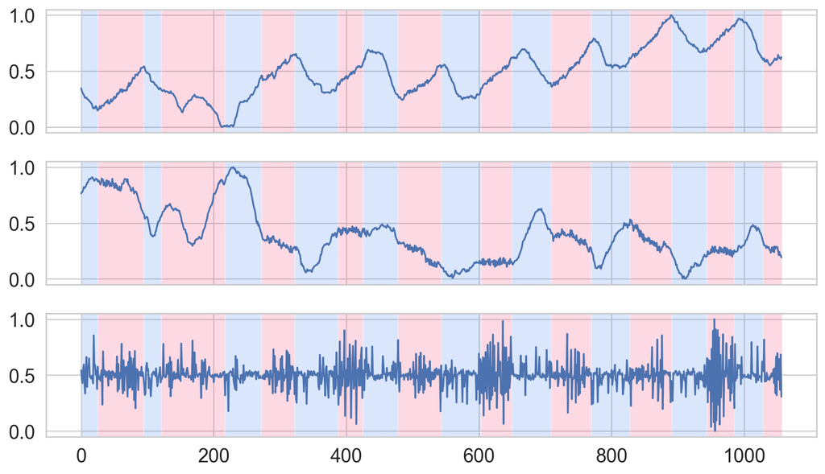

```python
rpt.display(data, cps);
```

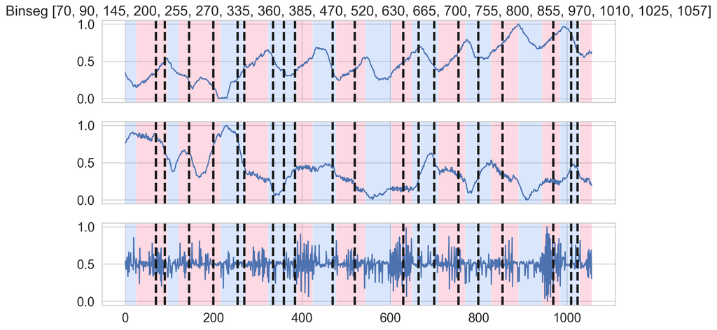

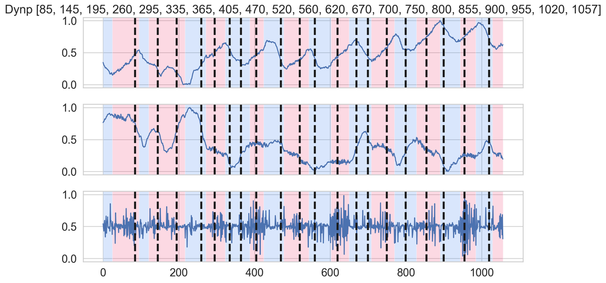

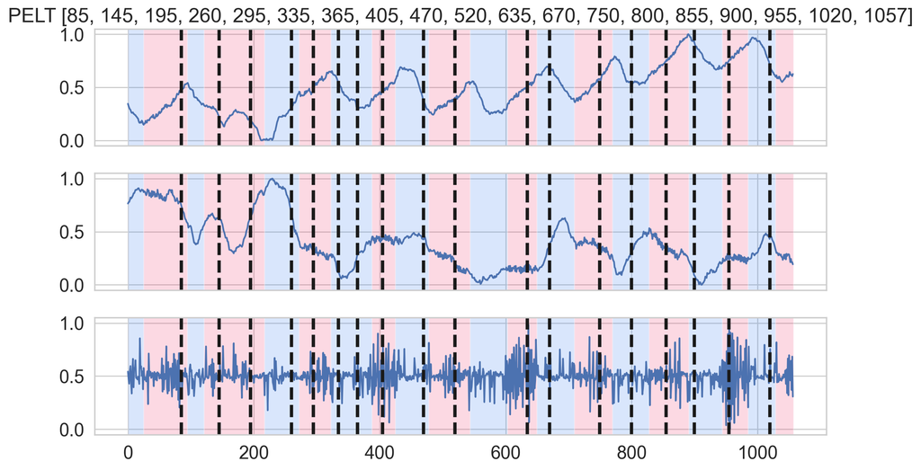

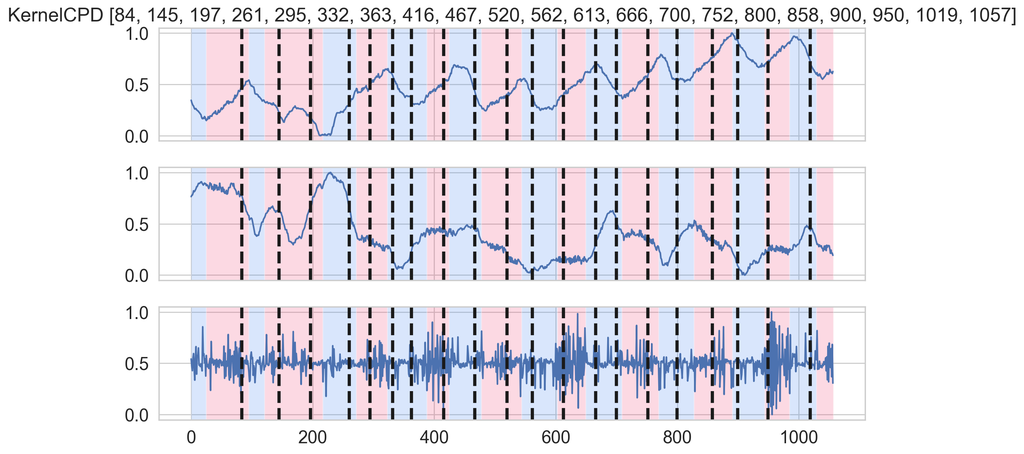

```python
n_cps = len(cps)
results_dict = dict()

algo = rpt.Binseg(model="l2").fit(data)
result_binseg = algo.predict(n_bkps=n_cps)
results_dict["binseg"] = result_binseg

fig, ax = rpt.display(data, cps, result_binseg)
ax[0].set_title(f"Binseg {result_binseg}")

algo = rpt.Dynp(model="l2").fit(data)
result_dynp = algo.predict(n_bkps=n_cps)
results_dict["dynp"] = result_dynp

fig, ax = rpt.display(data, cps, result_dynp)
ax[0].set_title(f"Dynp {result_dynp}")

algo = rpt.Pelt(model="l2").fit(data)
result_pelt = algo.predict(pen=0.7)
results_dict["pelt"] = result_pelt

fig, ax = rpt.display(data, cps, result_pelt)
ax[0].set_title(f"PELT {result_pelt}")

algo = rpt.KernelCPD(kernel="rbf").fit(data)
result_kernel = algo.predict(n_bkps=n_cps)
results_dict["kernel"] = result_kernel

fig, ax = rpt.display(data, cps, result_kernel)
ax[0].set_title(f"KernelCPD {result_kernel}");
```

```python
pd.DataFrame({
    model: [
        *precision_recall(cps, preds, margin=10),
        hausdorff(cps, preds),
        randindex(cps, preds)
    ]
    for model, preds in results_dict.items()
}, index=["Precision", "Recall", "Hausdorff metric", "Rand index"])
```

|  | binseg | dynp | pelt | kernel |
| --- | --- | --- | --- | --- |
| Precision | 0.300000 | 0.200000 | 0.166667 | 0.250000 |
| Recall | 0.315789 | 0.210526 | 0.157895 | 0.263158 |
| Hausdorff metric | 45.000000 | 60.000000 | 60.000000 | 59.000000 |
| Rand index | 0.949469 | 0.955380 | 0.950186 | 0.956989 |

## CUSUM

```python
data_raw = sio.loadmat("fishkiller.mat")
data = data_raw['Y']
target = data_raw['L']
subseq_len = 5000
data, target = data[:subseq_len], target[:subseq_len]
cps = list(np.where(np.diff(target.flatten()) != 0)[0])
cps.append(len(target))
```

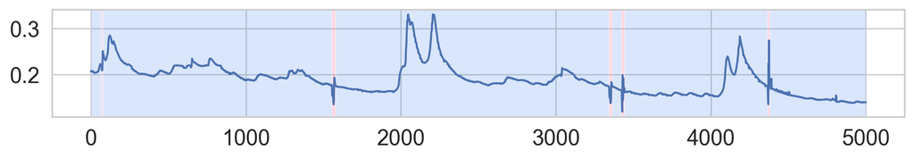

```python
rpt.display(data, cps);
```

```python
def cusum(data, threshold, drift=0):
    """
    Detects changes in the mean of a signal using the CUSUM method.

    Parameters:
        data (list or np.ndarray): The input time series data.
        threshold (float): The threshold value for detecting a change.
        drift (float): Drift parameter to adjust sensitivity to small changes (default: 0).

    Returns:
        list: indexes of changepoints
    """
    # Initialize variables
    g_pos = [0]  # Positive cumulative sum
    g_neg = [0]  # Negative cumulative sum
    signals = [0] * len(data)  # To store detection signals

    for i in range(1, len(data)):
        # Update positive and negative cumulative sums
        delta = data[i] - data[i - 1]
        g_pos.append(max(0, g_pos[-1] + delta - drift))
        g_neg.append(max(0, g_neg[-1] - delta - drift))

        # Detect change if threshold is exceeded
        if g_pos[-1] > threshold or g_neg[-1] > threshold:
            signals[i] = 1
            g_pos[-1], g_neg[-1] = 0, 0  # Reset after detection

    return list(np.where(signals)[0]) + [len(data)]
```

```python
result_cusum = cusum(data, 0.09)
```

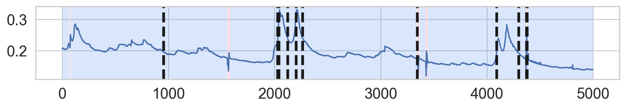

```python
rpt.display(data, cps, result_cusum);
```

```python
pd.DataFrame({
    model: [
        *precision_recall(cps, preds, margin=10),
        hausdorff(cps, preds),
        randindex(cps, preds)
    ]
    for model, preds in {"CUSUM": result_cusum}.items()
}, index=["Precision", "Recall", "Hausdorff metric", "Rand index"])
```

|  | CUSUM |
| --- | --- |
| Precision | 0.181818 |
| Recall | 0.200000 |
| Hausdorff metric | 888.000000 |
| Rand index | 0.838861 |

## More complex data

```python
!pip install librosa
```

[output not shown]

```python
import librosa
import librosa.display

from IPython.display import Audio, display
```

```
Downloading file 'Kevin_MacLeod_-_P_I_Tchaikovsky_Dance_of_the_Sugar_Plum_Fairy.ogg' from 'https://librosa.org/data/audio/Kevin_MacLeod_-_P_I_Tchaikovsky_Dance_of_the_Sugar_Plum_Fairy.ogg' to '/Users/nstulov/Library/Caches/librosa'.
```

[interactive chart not shown]

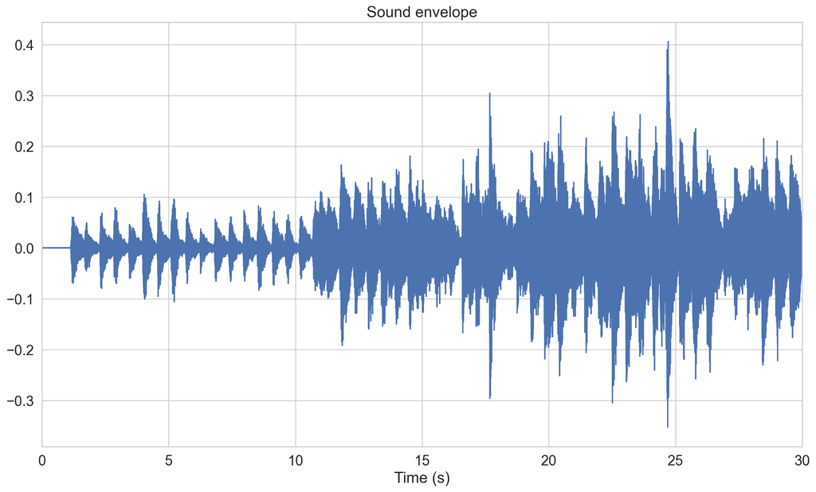

```python
duration = 30
signal, sampling_rate = librosa.load(librosa.ex("nutcracker"), duration=duration)

display(Audio(data=signal, rate=sampling_rate))

fig, ax = plt.subplots(figsize=(16,9))
ax.plot(np.arange(signal.size) / sampling_rate, signal)
ax.set_xlim(0, signal.size / sampling_rate)
ax.set_xlabel("Time (s)")
_ = ax.set(title="Sound envelope")
```

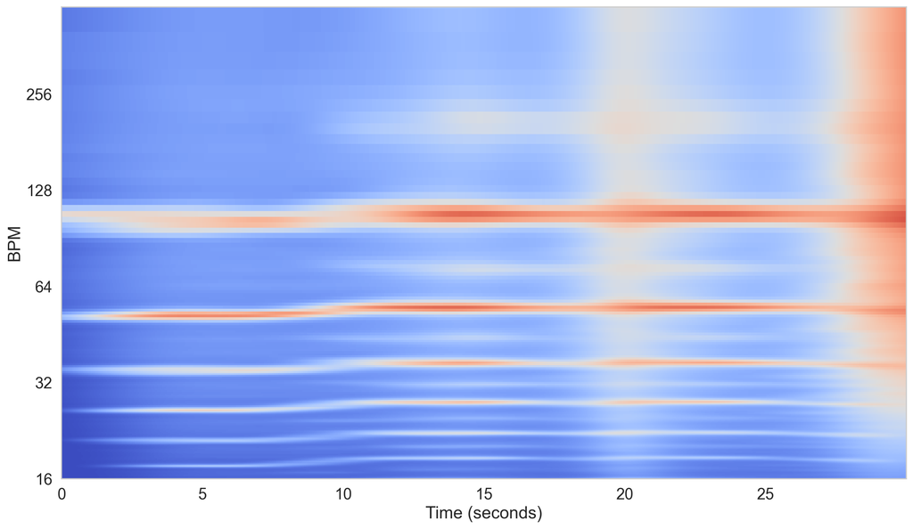

```python
oenv = librosa.onset.onset_strength(
    y=signal, sr=sampling_rate
)

tempogram = librosa.feature.tempogram(
    onset_envelope=oenv,
    sr=sampling_rate
)

fig, ax = plt.subplots(figsize=(16,9))
librosa.display.specshow(
    tempogram,
    ax=ax,
    sr=sampling_rate,
    x_axis="s",
    y_axis="tempo"
);
```

```
(0.0, 21.0)
```

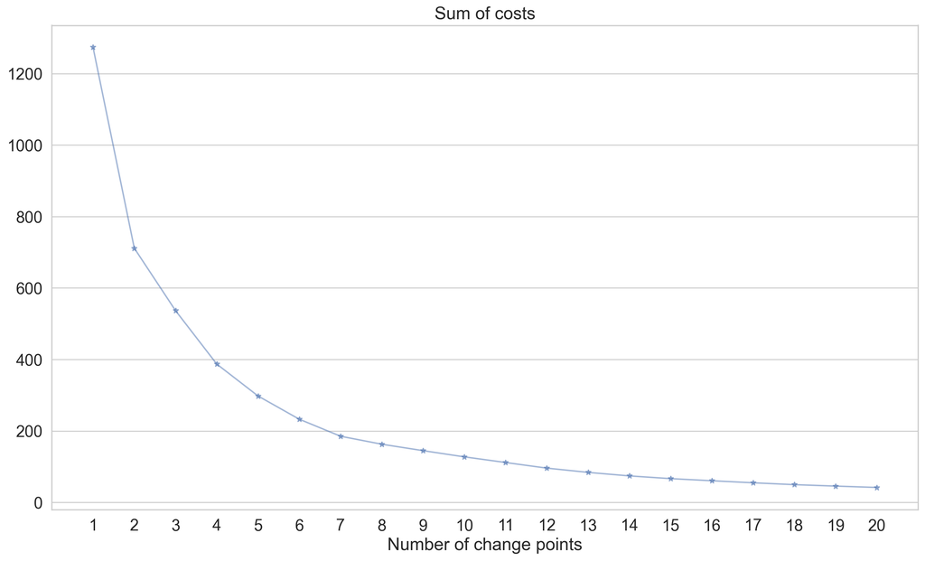

```python
algo = rpt.KernelCPD(kernel="linear").fit(tempogram.T)

n_cps_max = 20
algo.predict(n_cps_max);

array_of_n_cps = np.arange(1, n_cps_max + 1)

fig, ax = plt.subplots(figsize=(16,9))
ax.plot(
    array_of_n_cps,
    [algo.cost.sum_of_costs(algo.predict(n_bkps=n_cps)) for n_cps in array_of_n_cps],
    "-*",
    alpha=0.5,
)
ax.set_xticks(array_of_n_cps)
ax.set_xlabel("Number of change points")
ax.set_title("Sum of costs")
ax.grid(axis="x")
ax.set_xlim(0, n_cps_max + 1)
```

```python
n_cps = 7
```

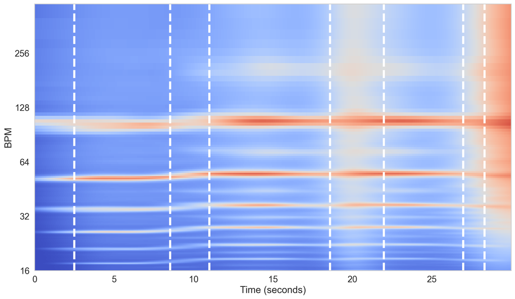

```python
cps = algo.predict(n_bkps=n_cps)
cps_times = librosa.frames_to_time(cps, sr=sampling_rate)

# Displaying results
fig, ax = plt.subplots(figsize=(16,9))
librosa.display.specshow(
    tempogram,
    ax=ax,
    x_axis="s",
    y_axis="tempo",
    sr=sampling_rate,
)

for b in cps_times[:-1]:
    ax.axvline(b, ls="--", color="white", lw=4)
```

```python
cps_time_indexes = (sampling_rate * cps_times).astype(int).tolist()

for (segment_number, (start, end)) in enumerate(
    rpt.utils.pairwise([0] + cps_time_indexes), start=1
):
    segment = signal[start:end]
    display(Audio(data=segment, rate=sampling_rate))
```

[interactive chart not shown]

## NN methods

Classical CPD methods can't be directly applied to complex unstructured data like videos. In order to work with such data, we can proceed in two ways:

1. Get representations and apply classical CPD on top of them
2. Develop and end-to-end NN solution for CPD

```python
!git clone https://github.com/Sudo42b/TSCP2_pytorch.git
```

```
Cloning into 'TSCP2_pytorch'...
remote: Enumerating objects: 78, done.
remote: Counting objects: 100% (78/78), done.
remote: Compressing objects: 100% (54/54), done.
remote: Total 78 (delta 27), reused 67 (delta 19), pack-reused 0 (from 0)
Receiving objects: 100% (78/78), 64.06 KiB | 455.00 KiB/s, done.
Resolving deltas: 100% (27/27), done.
```